# Get Paleo Biogeographic data for Africa and Madagascar

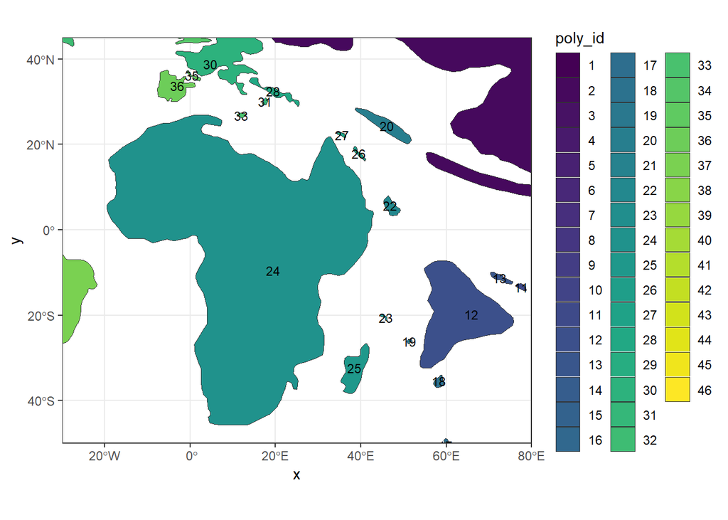

```r
i <- 3


pc <- paleo_coasts_list[[i]] %>%
  sf::st_cast("POLYGON") %>%
  mutate(poly_id = row_number())

ggplot(pc) +
  geom_sf(aes(fill = factor(poly_id)), color = "grey20", linewidth = 0.2) +
  geom_sf_text(aes(label = poly_id), size = 3, check_overlap = TRUE) +
  scale_fill_viridis_d(name = "poly_id") +
  coord_sf(
    xlim = c(-30, 80),
    ylim = c(-50, 45),
    expand = FALSE
  ) +
  theme_bw()
```

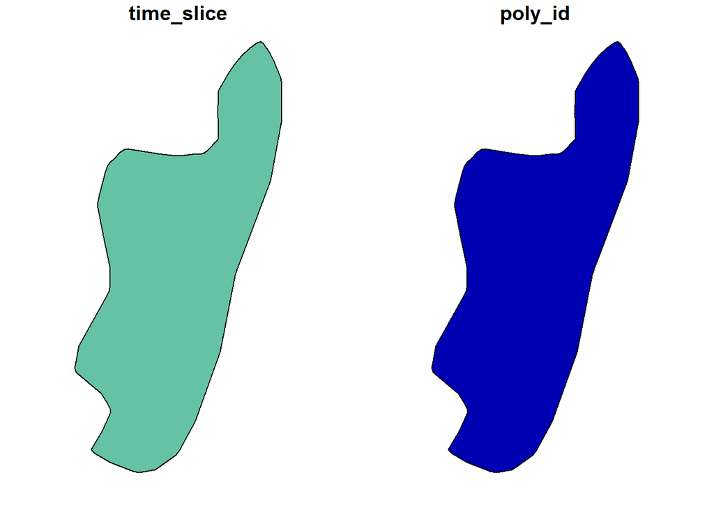

```r
id <- 25

pc %>%
  filter(poly_id == id) %>%
  plot()
```

```r
mda_list[[i]] <-
  pc %>%
  filter(poly_id == id) %>%
  summarize(region = "Madagascar", time_slice = unique(time_slice))
```

```
although coordinates are longitude/latitude, st_union assumes that they are
planar
```

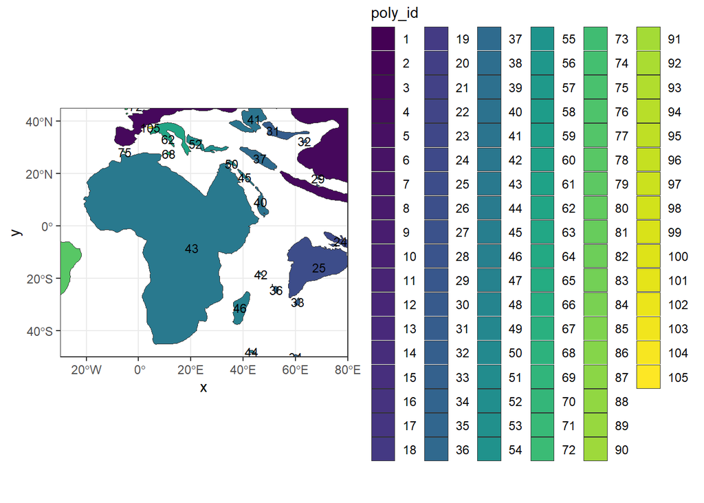

```r
i <- 4

pc <- paleo_coasts_list[[i]] %>%
  sf::st_cast("POLYGON") %>%
  mutate(poly_id = row_number())

ggplot(pc) +
  geom_sf(aes(fill = factor(poly_id)), color = "grey20", linewidth = 0.2) +
  geom_sf_text(aes(label = poly_id), size = 3, check_overlap = TRUE) +
  scale_fill_viridis_d(name = "poly_id") +
  coord_sf(
    xlim = c(-30, 80),
    ylim = c(-50, 45),
    expand = FALSE
  ) +
  theme_bw()
```

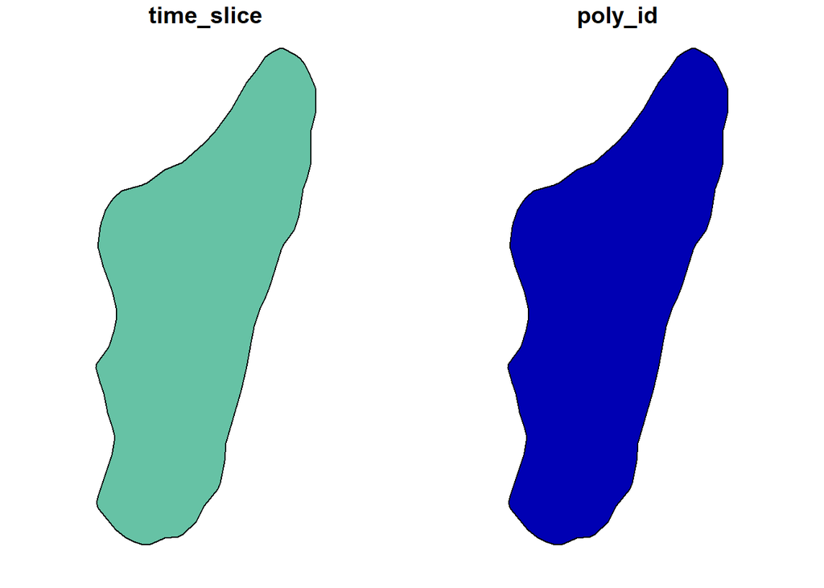

```r
id <- 46

pc %>%
  filter(poly_id == id) %>%
  plot()
```

```r
mda_list[[i]] <-
  pc %>%
  filter(poly_id == id) %>%
  summarize(region = "Madagascar", time_slice = unique(time_slice))
```

```
although coordinates are longitude/latitude, st_union assumes that they are
planar
```

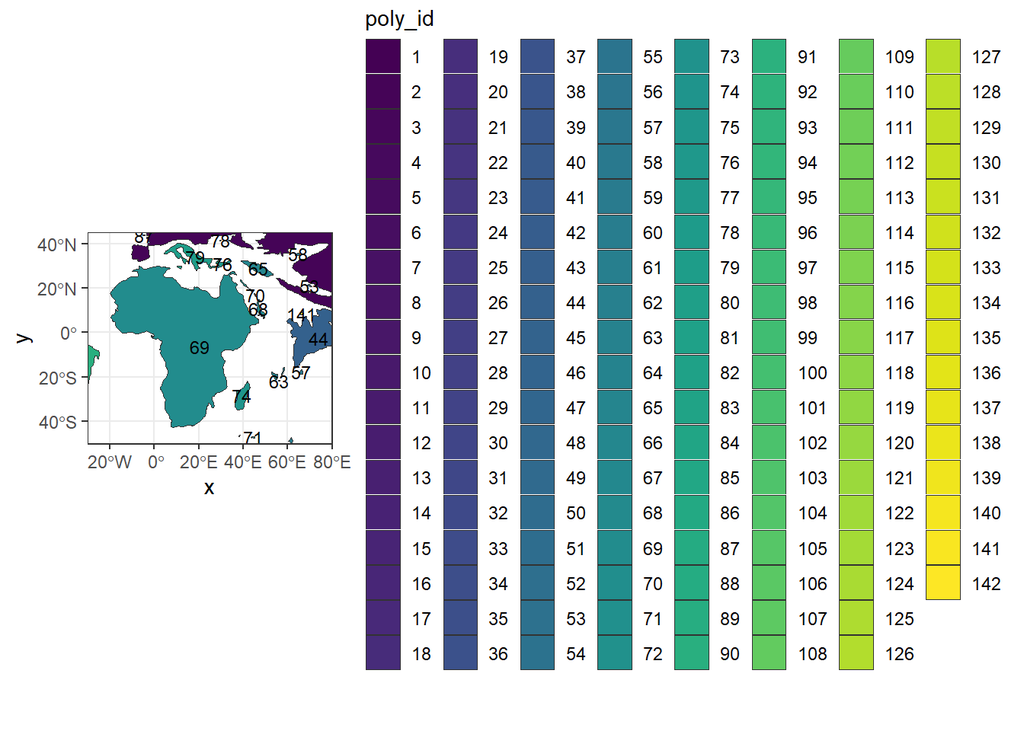

```r
i <- 5

pc <- paleo_coasts_list[[i]] %>%
  sf::st_cast("POLYGON") %>%
  mutate(poly_id = row_number())

ggplot(pc) +
  geom_sf(aes(fill = factor(poly_id)), color = "grey20", linewidth = 0.2) +
  geom_sf_text(aes(label = poly_id), size = 3, check_overlap = TRUE) +
  scale_fill_viridis_d(name = "poly_id") +
  coord_sf(
    xlim = c(-30, 80),
    ylim = c(-50, 45),
    expand = FALSE
  ) +
  theme_bw()
```

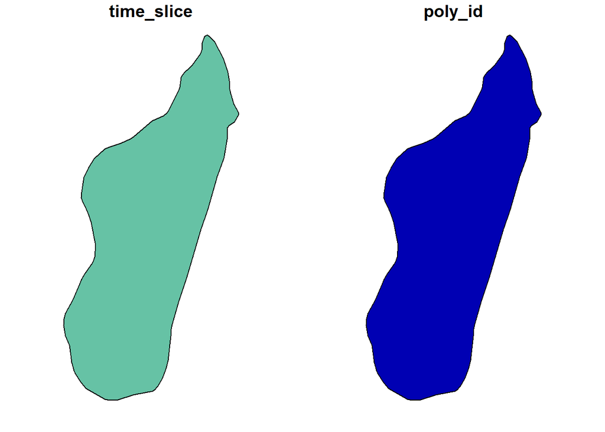

```r
id <- 74

pc %>%
  filter(poly_id == id) %>%
  plot()
```

```r
mda_list[[i]] <-
  pc %>%
  filter(poly_id == id) %>%
  summarize(region = "Madagascar", time_slice = unique(time_slice))
```

```
although coordinates are longitude/latitude, st_union assumes that they are
planar
```

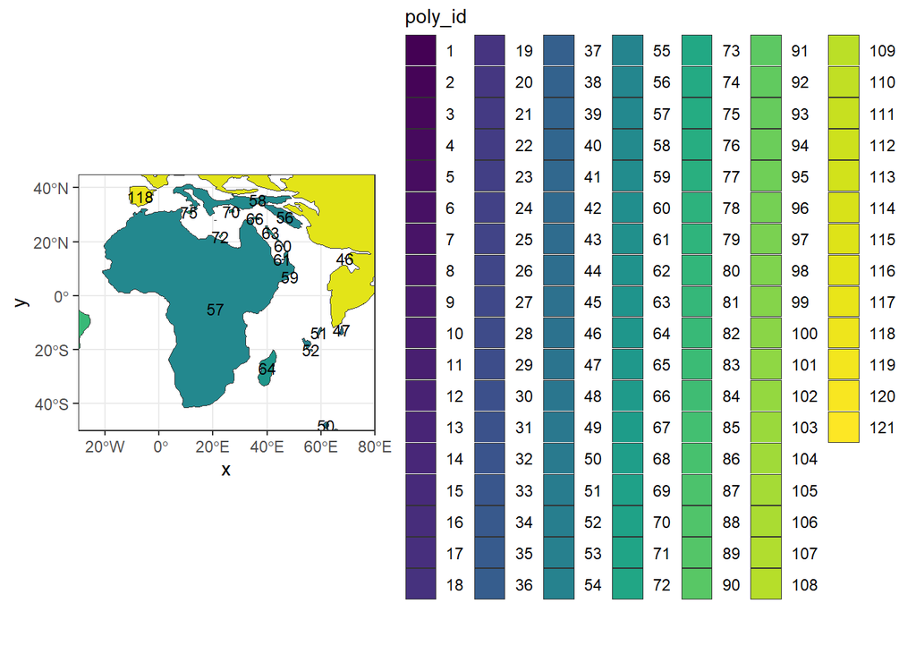

```r
i <- 6

pc <- paleo_coasts_list[[i]] %>%
  sf::st_cast("POLYGON") %>%
  mutate(poly_id = row_number())

ggplot(pc) +
  geom_sf(aes(fill = factor(poly_id)), color = "grey20", linewidth = 0.2) +
  geom_sf_text(aes(label = poly_id), size = 3, check_overlap = TRUE) +
  scale_fill_viridis_d(name = "poly_id") +
  coord_sf(
    xlim = c(-30, 80),
    ylim = c(-50, 45),
    expand = FALSE
  ) +
  theme_bw()
```

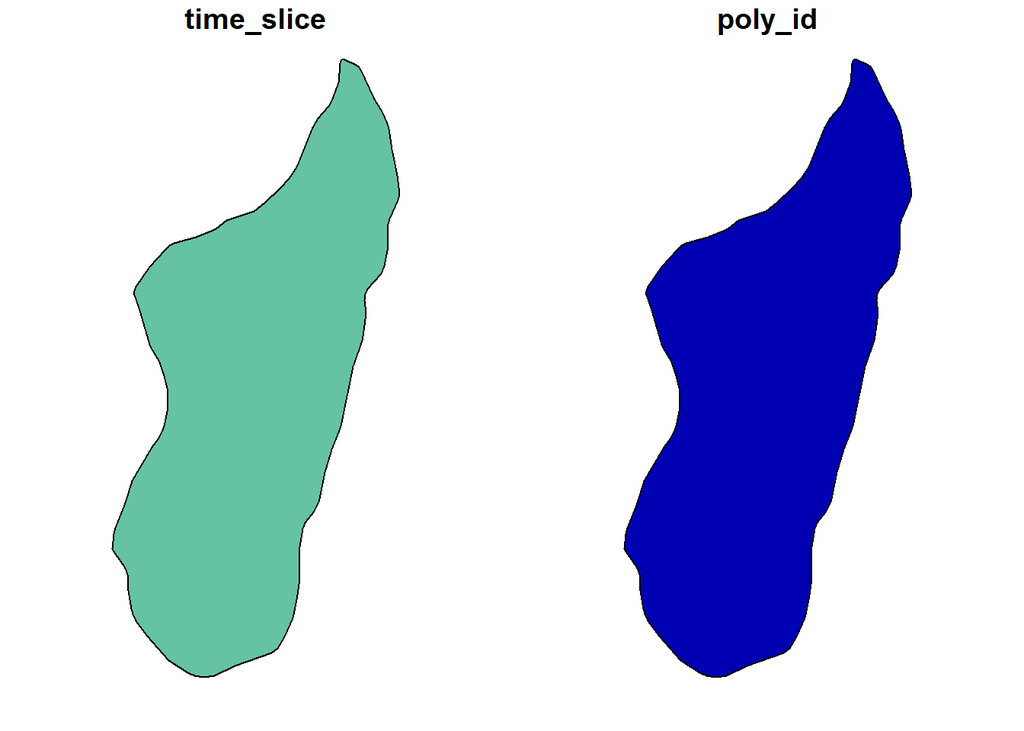

```r
id <- 64

pc %>%
  filter(poly_id == id) %>%
  plot()
```

```r
mda_list[[i]] <-
  pc %>%
  filter(poly_id == id) %>%
  summarize(region = "Madagascar", time_slice = unique(time_slice))
```

```
although coordinates are longitude/latitude, st_union assumes that they are
planar
```

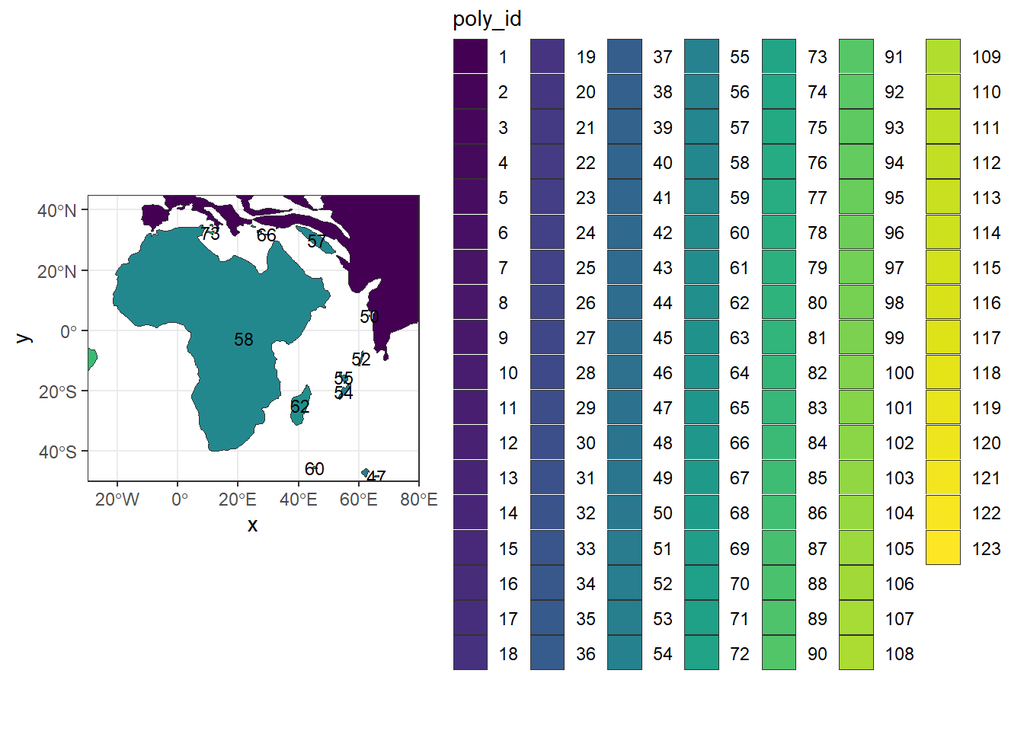

```r
i <- 7

pc <- paleo_coasts_list[[i]] %>%
  sf::st_cast("POLYGON") %>%
  mutate(poly_id = row_number())

ggplot(pc) +
  geom_sf(aes(fill = factor(poly_id)), color = "grey20", linewidth = 0.2) +
  geom_sf_text(aes(label = poly_id), size = 3, check_overlap = TRUE) +
  scale_fill_viridis_d(name = "poly_id") +
  coord_sf(
    xlim = c(-30, 80),
    ylim = c(-50, 45),
    expand = FALSE
  ) +
  theme_bw()
```

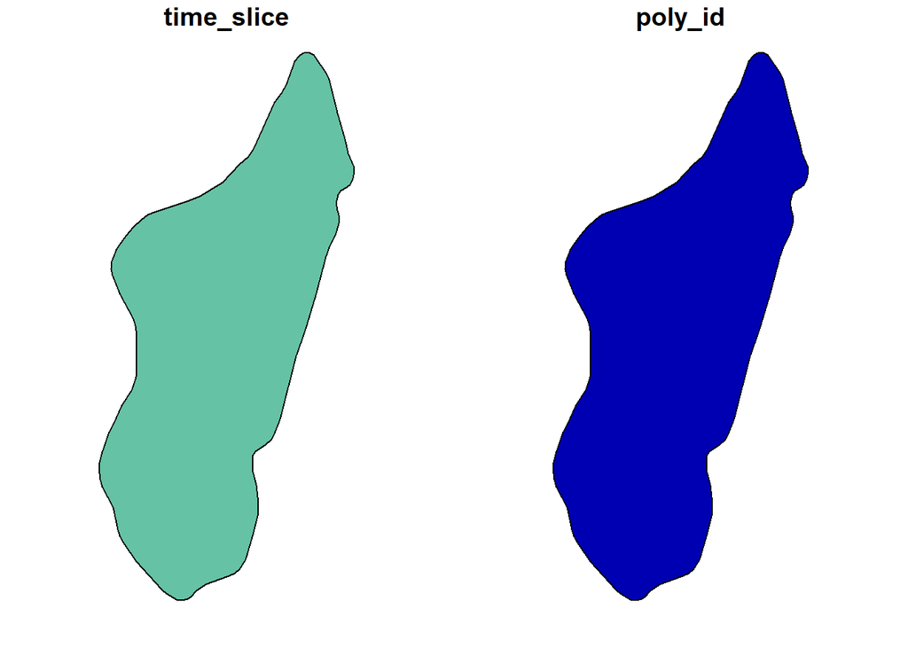

```r
id <- 62

pc %>%
  filter(poly_id == id) %>%
  plot()
```

```r
mda_list[[i]] <-
  pc %>%
  filter(poly_id == id) %>%
  summarize(region = "Madagascar", time_slice = unique(time_slice))
```

```
although coordinates are longitude/latitude, st_union assumes that they are
planar
```

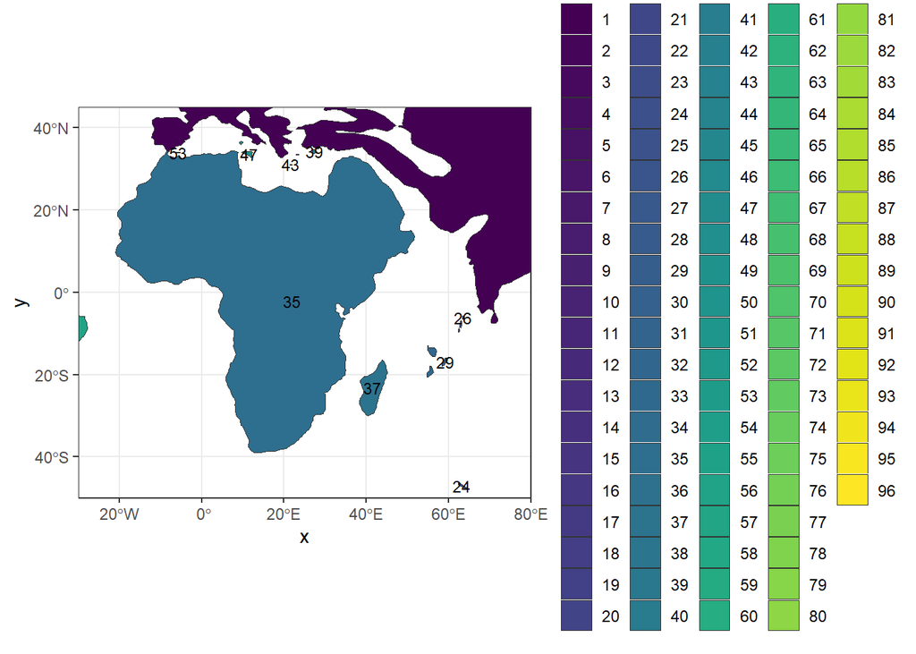

```r
i <- 8


pc <- paleo_coasts_list[[i]] %>%
  sf::st_cast("POLYGON") %>%
  mutate(poly_id = row_number())

ggplot(pc) +
  geom_sf(aes(fill = factor(poly_id)), color = "grey20", linewidth = 0.2) +
  geom_sf_text(aes(label = poly_id), size = 3, check_overlap = TRUE) +
  scale_fill_viridis_d(name = "poly_id") +
  coord_sf(
    xlim = c(-30, 80),
    ylim = c(-50, 45),
    expand = FALSE
  ) +
  theme_bw()
```

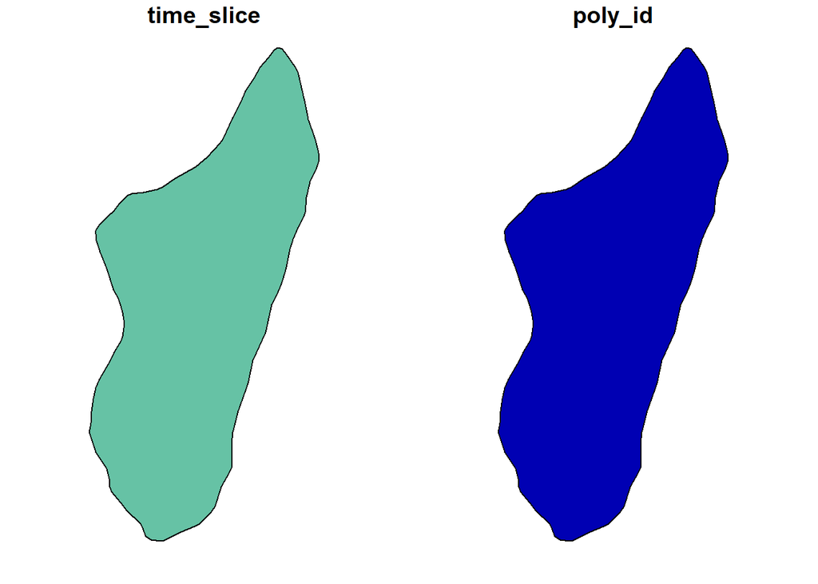

```r
id <- 37

pc %>%
  filter(poly_id == id) %>%
  plot()
```

```r
mda_list[[i]] <-
  pc %>%
  filter(poly_id == id) %>%
  summarize(region = "Madagascar", time_slice = unique(time_slice))
```

```
although coordinates are longitude/latitude, st_union assumes that they are
planar
```

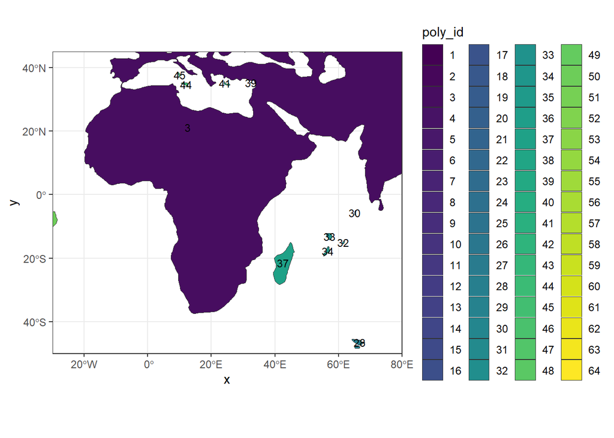

```r
i <- 9

pc <- paleo_coasts_list[[i]] %>%
  sf::st_cast("POLYGON") %>%
  mutate(poly_id = row_number())

ggplot(pc) +
  geom_sf(aes(fill = factor(poly_id)), color = "grey20", linewidth = 0.2) +
  geom_sf_text(aes(label = poly_id), size = 3, check_overlap = TRUE) +
  scale_fill_viridis_d(name = "poly_id") +
  coord_sf(
    xlim = c(-30, 80),
    ylim = c(-50, 45),
    expand = FALSE
  ) +
  theme_bw()
```

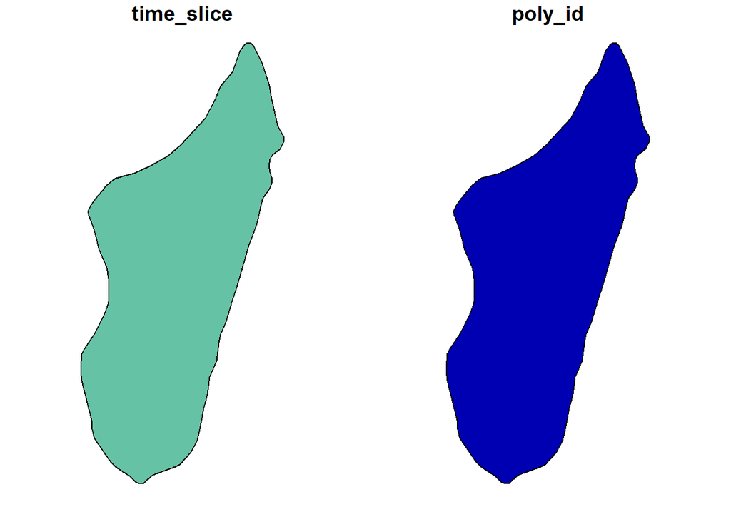

```r
id <- 37

pc %>%
  filter(poly_id == id) %>%
  plot()
```

```r
mda_list[[i]] <-
  pc %>%
  filter(poly_id == id) %>%
  summarize(region = "Madagascar", time_slice = unique(time_slice))
```

```
although coordinates are longitude/latitude, st_union assumes that they are
planar
```

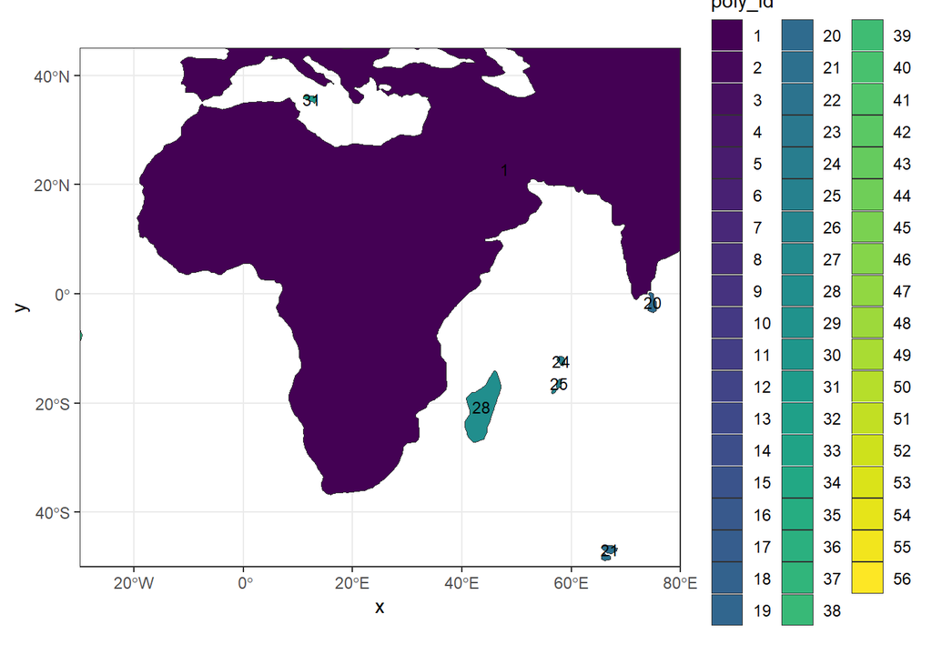

```r
i <- 10


pc <- paleo_coasts_list[[i]] %>%
  sf::st_cast("POLYGON") %>%
  mutate(poly_id = row_number())

ggplot(pc) +
  geom_sf(aes(fill = factor(poly_id)), color = "grey20", linewidth = 0.2) +
  geom_sf_text(aes(label = poly_id), size = 3, check_overlap = TRUE) +
  scale_fill_viridis_d(name = "poly_id") +
  coord_sf(
    xlim = c(-30, 80),
    ylim = c(-50, 45),
    expand = FALSE
  ) +
  theme_bw()
```

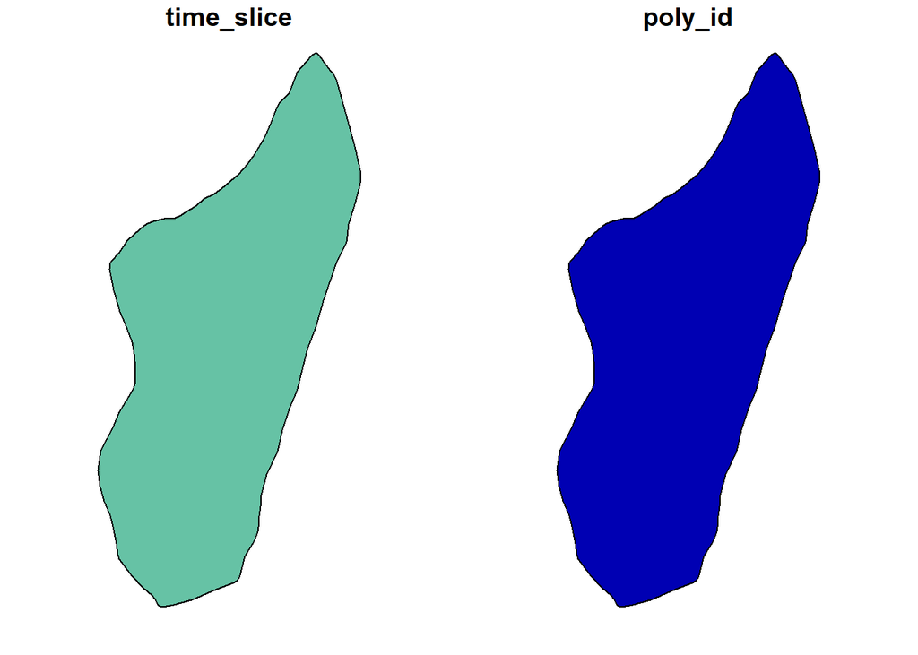

```r
id <- 28

pc %>%
  filter(poly_id == id) %>%
  plot()
```

```r
mda_list[[i]] <-
  pc %>%
  filter(poly_id == id) %>%
  summarize(region = "Madagascar", time_slice = unique(time_slice))
```

```
although coordinates are longitude/latitude, st_union assumes that they are
planar
```

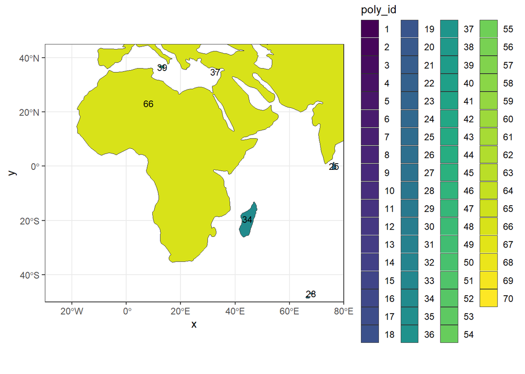

```r
i <- 11


pc <- paleo_coasts_list[[i]] %>%
  sf::st_cast("POLYGON") %>%
  mutate(poly_id = row_number())

ggplot(pc) +
  geom_sf(aes(fill = factor(poly_id)), color = "grey20", linewidth = 0.2) +
  geom_sf_text(aes(label = poly_id), size = 3, check_overlap = TRUE) +
  scale_fill_viridis_d(name = "poly_id") +
  coord_sf(
    xlim = c(-30, 80),
    ylim = c(-50, 45),
    expand = FALSE
  ) +
  theme_bw()
```

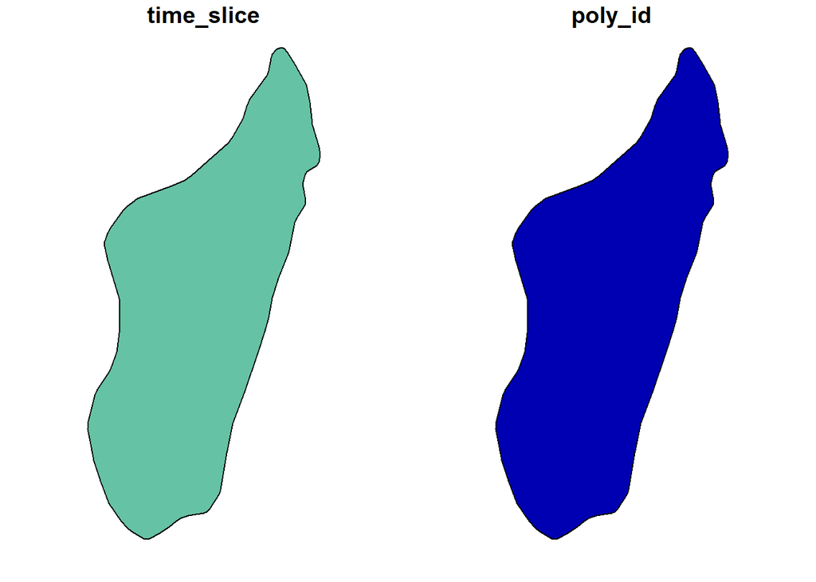

```r
id <- 34

pc %>%
  filter(poly_id == id) %>%
  plot()
```

```r
mda_list[[i]] <-
  pc %>%
  filter(poly_id == id) %>%
  summarize(region = "Madagascar", time_slice = unique(time_slice))
```

```
although coordinates are longitude/latitude, st_union assumes that they are
planar
```

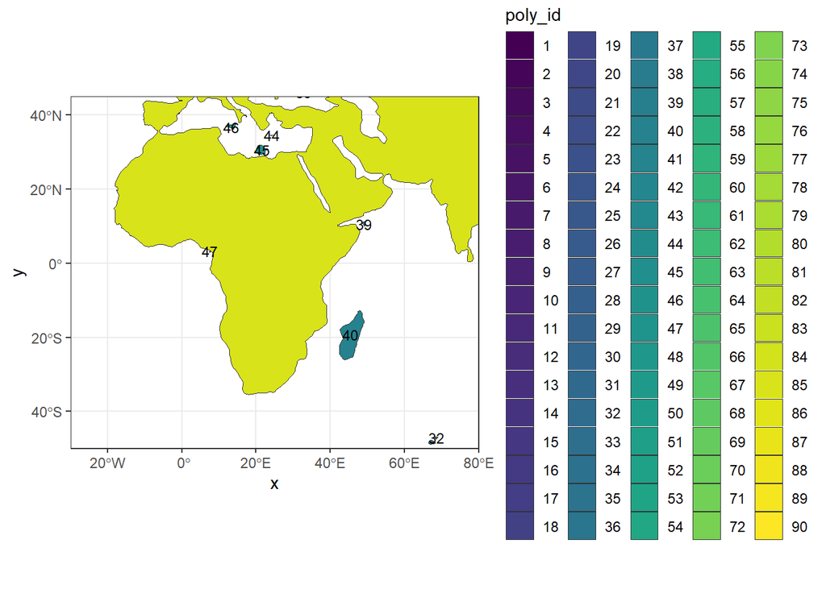

```r
i <- 12


pc <- paleo_coasts_list[[i]] %>%
  sf::st_cast("POLYGON") %>%
  mutate(poly_id = row_number())

ggplot(pc) +
  geom_sf(aes(fill = factor(poly_id)), color = "grey20", linewidth = 0.2) +
  geom_sf_text(aes(label = poly_id), size = 3, check_overlap = TRUE) +
  scale_fill_viridis_d(name = "poly_id") +
  coord_sf(
    xlim = c(-30, 80),
    ylim = c(-50, 45),
    expand = FALSE
  ) +
  theme_bw()
```

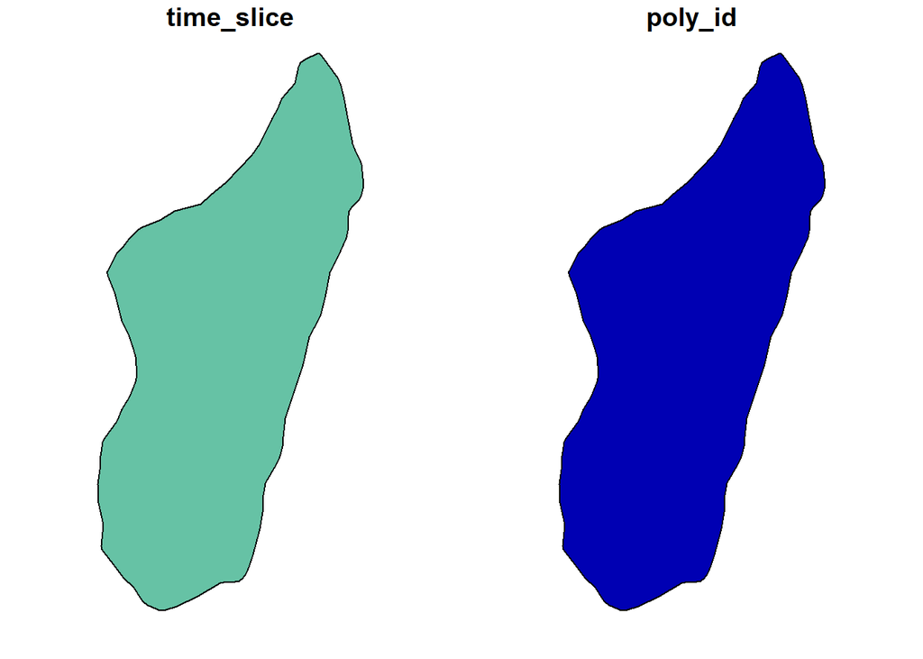

```r
id <- 40

pc %>%
  filter(poly_id == id) %>%
  plot()
```

```r
mda_list[[i]] <-
  pc %>%
  filter(poly_id == id) %>%
  summarize(region = "Madagascar", time_slice = unique(time_slice))
```

```
although coordinates are longitude/latitude, st_union assumes that they are
planar
```

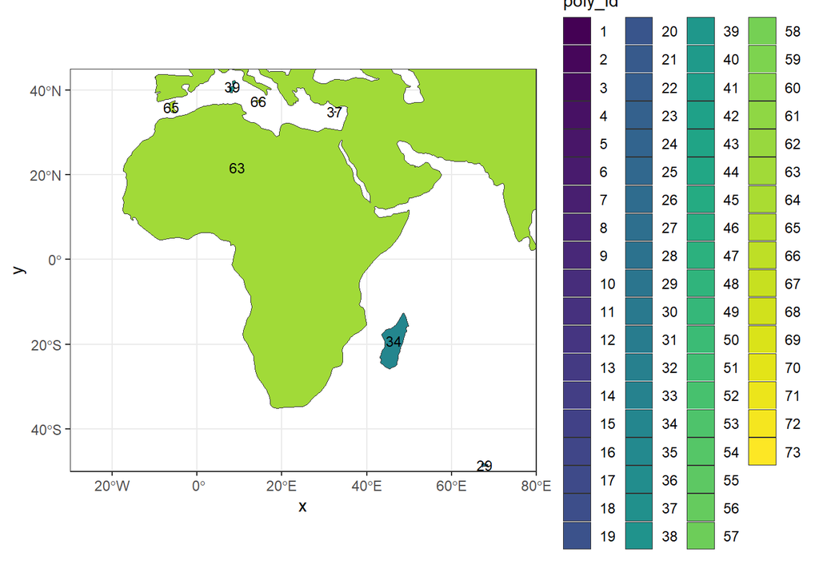

```r
i <- 13


pc <- paleo_coasts_list[[i]] %>%
  sf::st_cast("POLYGON") %>%
  mutate(poly_id = row_number())

ggplot(pc) +
  geom_sf(aes(fill = factor(poly_id)), color = "grey20", linewidth = 0.2) +
  geom_sf_text(aes(label = poly_id), size = 3, check_overlap = TRUE) +
  scale_fill_viridis_d(name = "poly_id") +
  coord_sf(
    xlim = c(-30, 80),
    ylim = c(-50, 45),
    expand = FALSE
  ) +
  theme_bw()
```

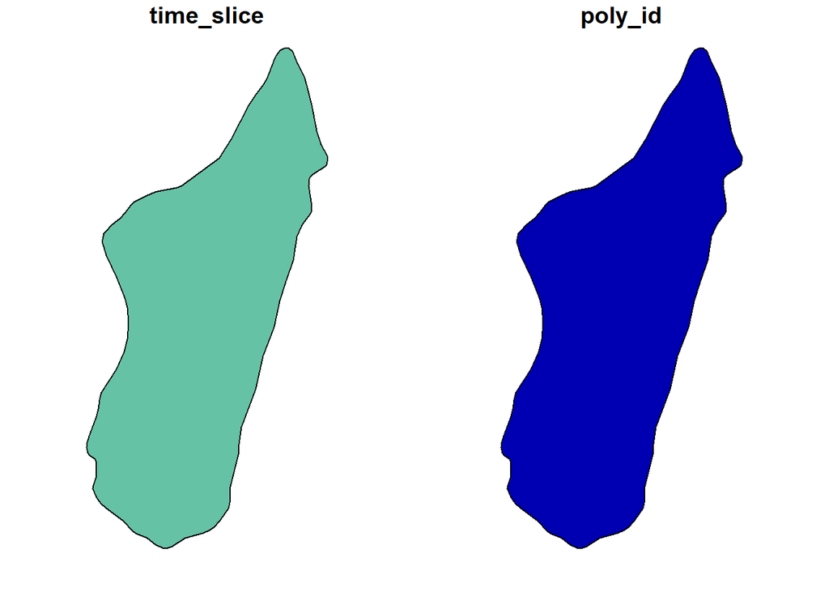

```r
id <- 34

pc %>%
  filter(poly_id == id) %>%
  plot()
```

```r
mda_list[[i]] <-
  pc %>%
  filter(poly_id == id) %>%
  summarize(region = "Madagascar", time_slice = unique(time_slice))
```

```
although coordinates are longitude/latitude, st_union assumes that they are
planar
```

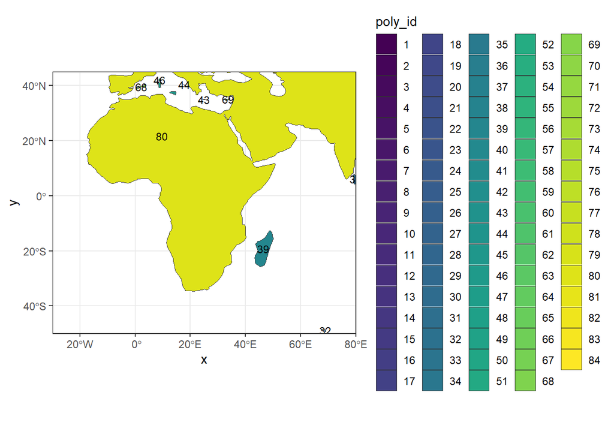

```r
i <- 14


pc <- paleo_coasts_list[[i]] %>%
  sf::st_cast("POLYGON") %>%
  mutate(poly_id = row_number())

ggplot(pc) +
  geom_sf(aes(fill = factor(poly_id)), color = "grey20", linewidth = 0.2) +
  geom_sf_text(aes(label = poly_id), size = 3, check_overlap = TRUE) +
  scale_fill_viridis_d(name = "poly_id") +
  coord_sf(
    xlim = c(-30, 80),
    ylim = c(-50, 45),
    expand = FALSE
  ) +
  theme_bw()
```

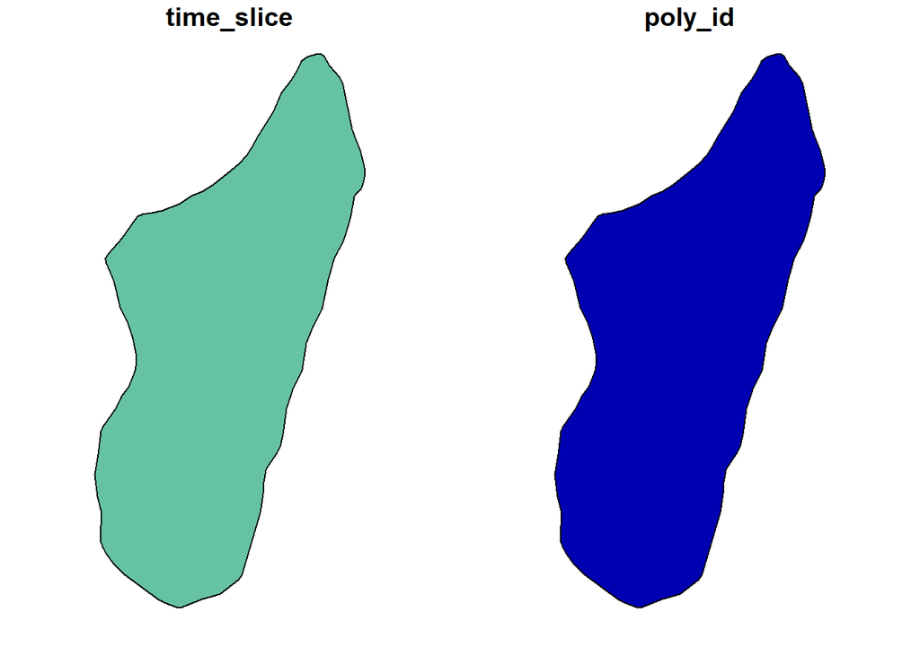

```r
id <- 39

pc %>%
  filter(poly_id == id) %>%
  plot()
```

```r
mda_list[[i]] <-
  pc %>%
  filter(poly_id == id) %>%
  summarize(region = "Madagascar", time_slice = unique(time_slice))
```

```
although coordinates are longitude/latitude, st_union assumes that they are
planar
```

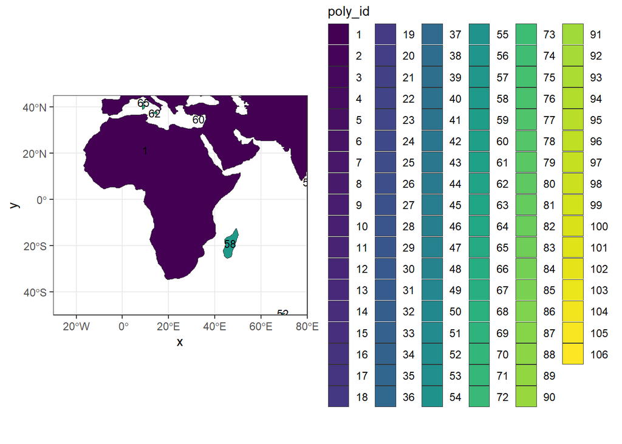

```r
i <- 15


pc <- paleo_coasts_list[[i]] %>%
  sf::st_cast("POLYGON") %>%
  mutate(poly_id = row_number())

ggplot(pc) +
  geom_sf(aes(fill = factor(poly_id)), color = "grey20", linewidth = 0.2) +
  geom_sf_text(aes(label = poly_id), size = 3, check_overlap = TRUE) +
  scale_fill_viridis_d(name = "poly_id") +
  coord_sf(
    xlim = c(-30, 80),
    ylim = c(-50, 45),
    expand = FALSE
  ) +
  theme_bw()
```

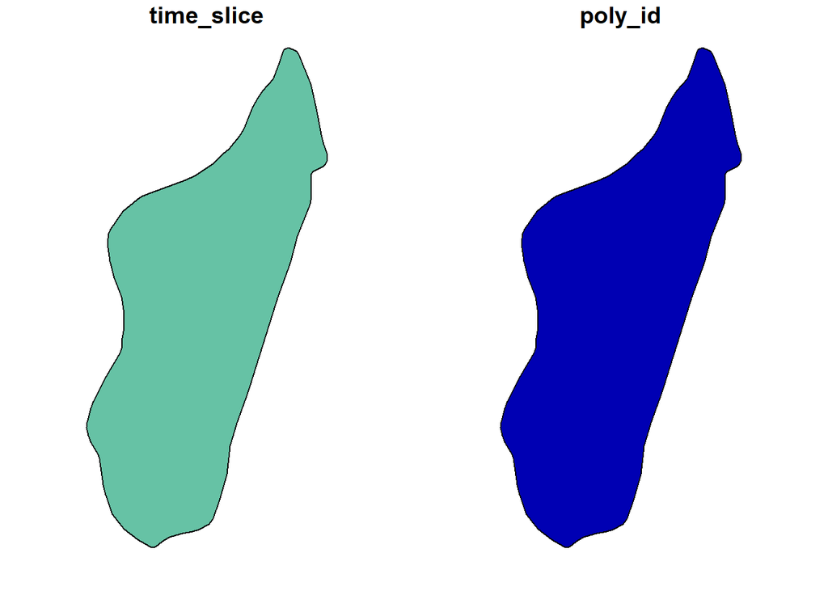

```r
id <- 58

pc %>%
  filter(poly_id == id) %>%
  plot()
```

```r
mda_list[[i]] <-
  pc %>%
  filter(poly_id == id) %>%
  summarize(region = "Madagascar", time_slice = unique(time_slice))
```

```
although coordinates are longitude/latitude, st_union assumes that they are
planar
```

```r
# let's save this for later reference
madagascar_extraction_df <-
  data.frame(
    time_slice = seq(1:15),
    id = c(30, 40, 25, 46, 74, 64, 62, 37, 37, 28, 34, 40, 34, 39, 58),
    ages
  )
```

### 4. Calculate Area and Distances

To get more or less accurate estimations of area and distance we have to project the data to an equal area projection (spherical)

```r
# our two lists are:
# mda_list
# afr_list

aea <- 6933

sf_use_s2(TRUE) # use spherical geometry package
```

```
Spherical geometry (s2) switched on
```

```
Processing 80 Ma
```

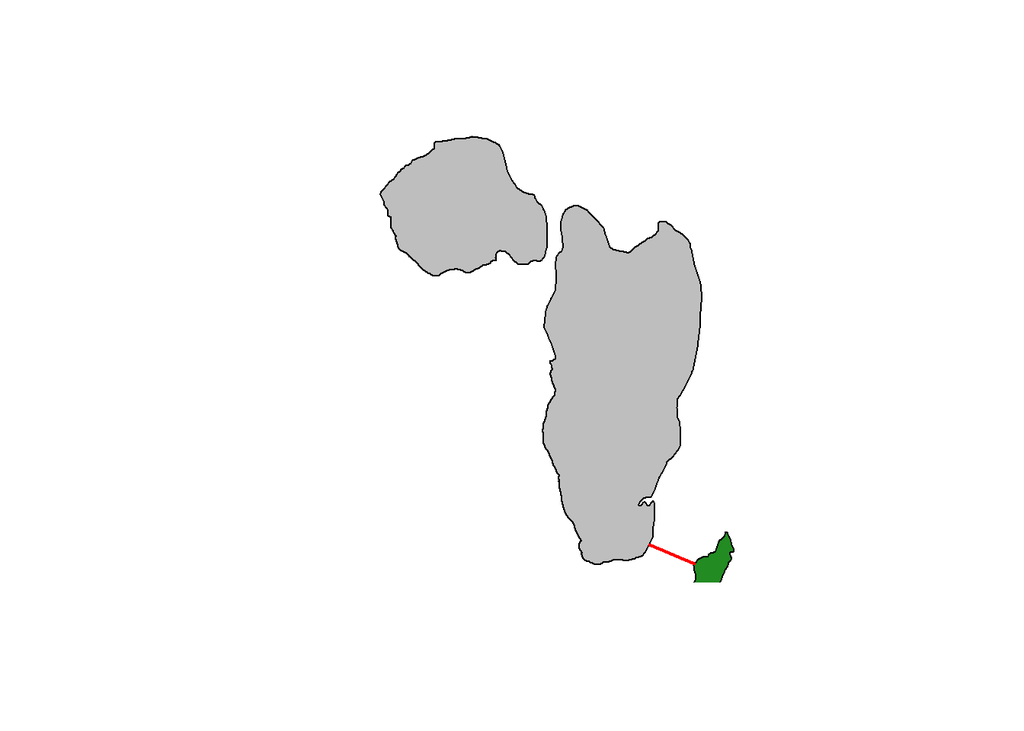

```
Processing 70 Ma
```

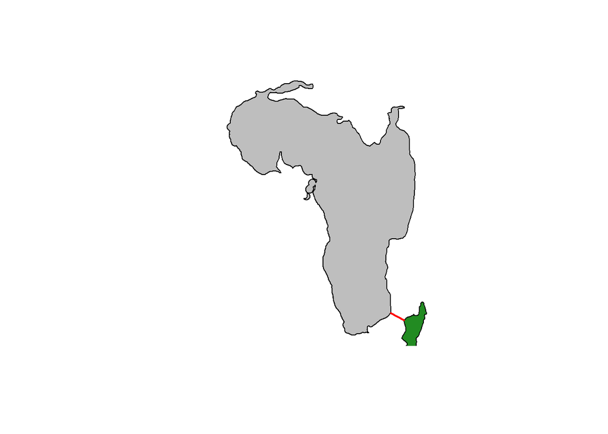

```
Processing 65 Ma
```

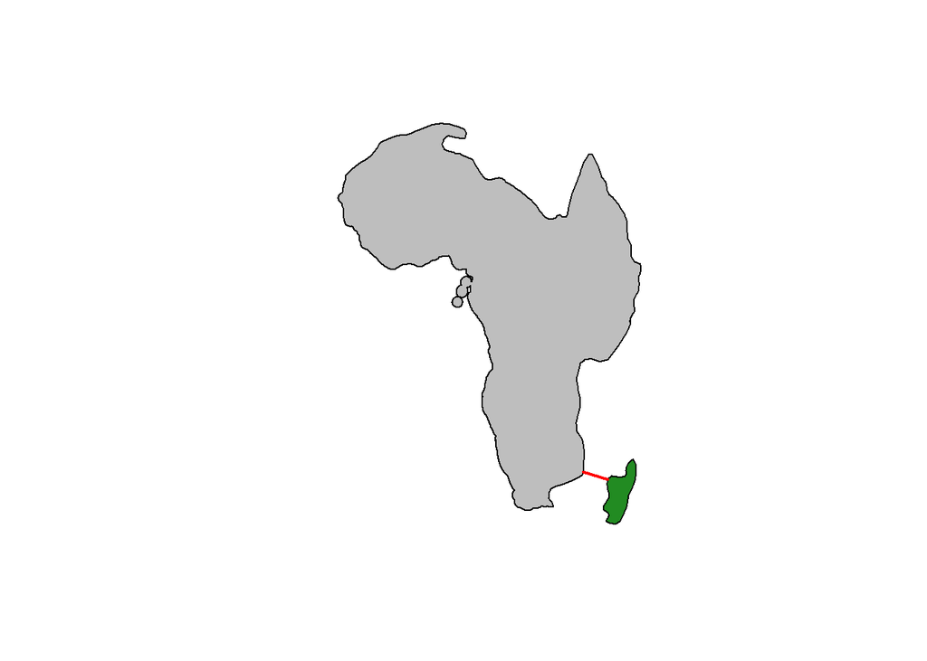

```
Processing 60 Ma
```

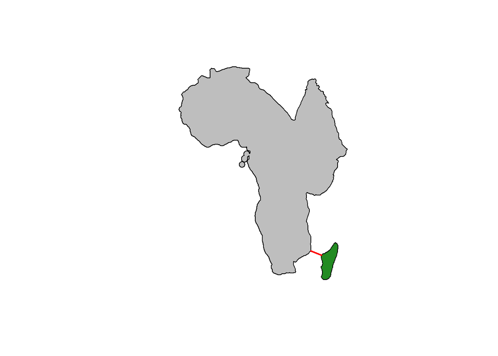

```
Processing 50 Ma
```

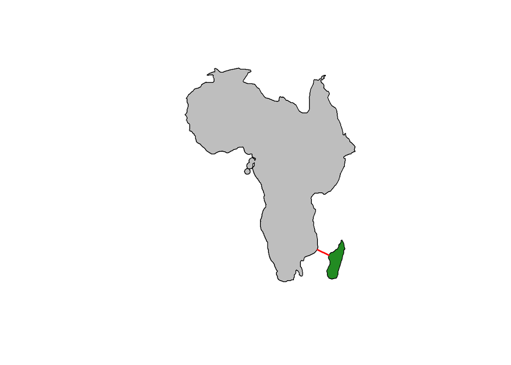

```
Processing 45 Ma
```

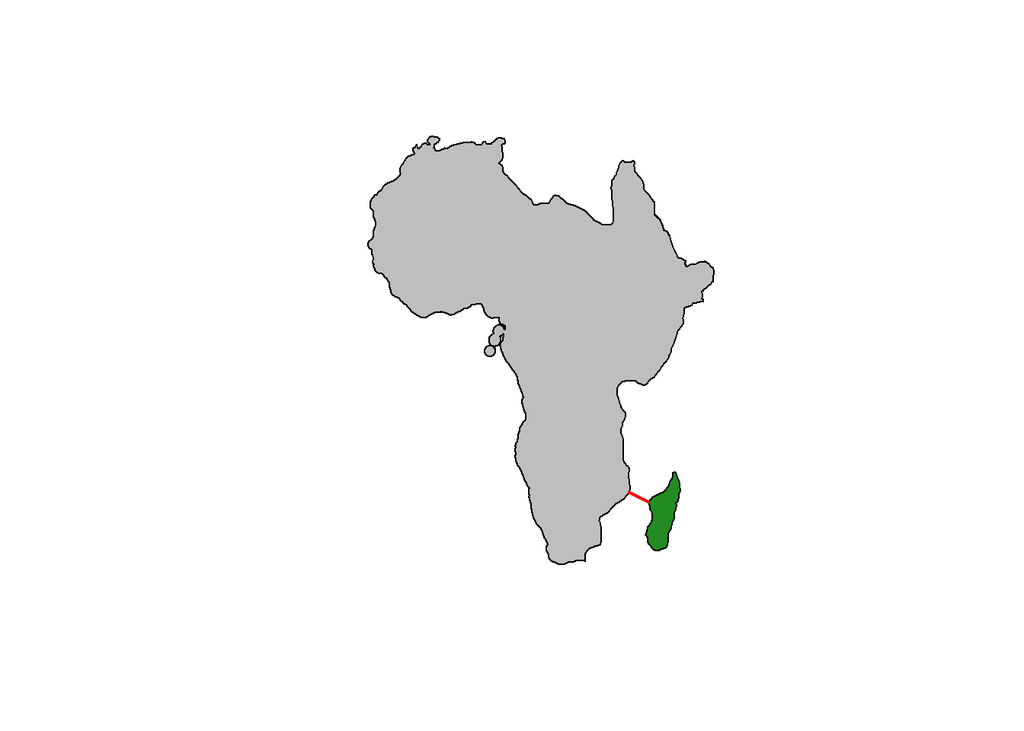

```
Processing 40 Ma
```

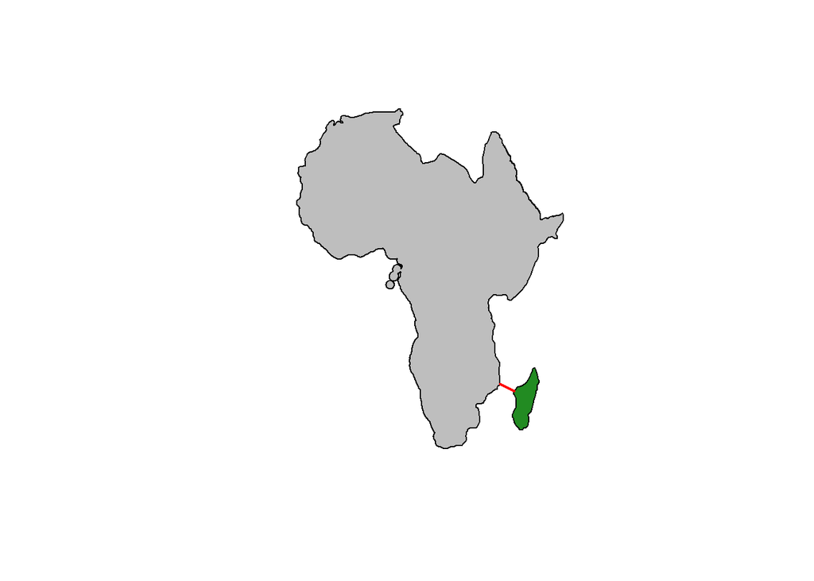

```
Processing 35 Ma
```

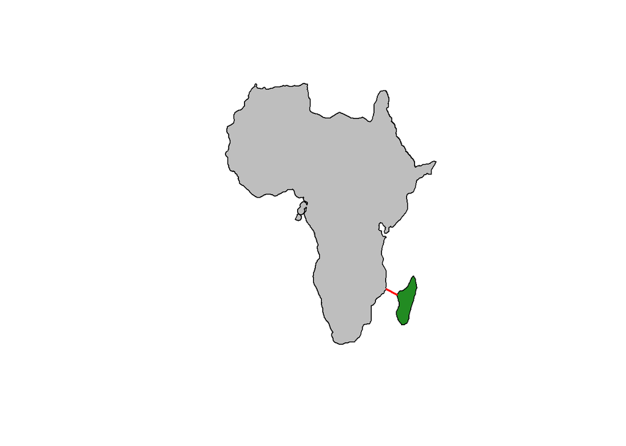

```
Processing 30 Ma
```

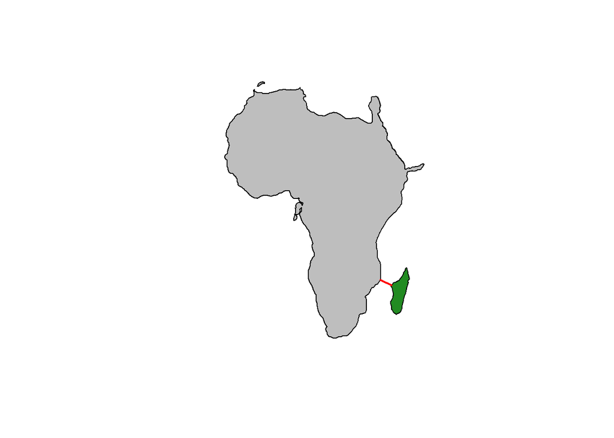

```
Processing 25 Ma
```

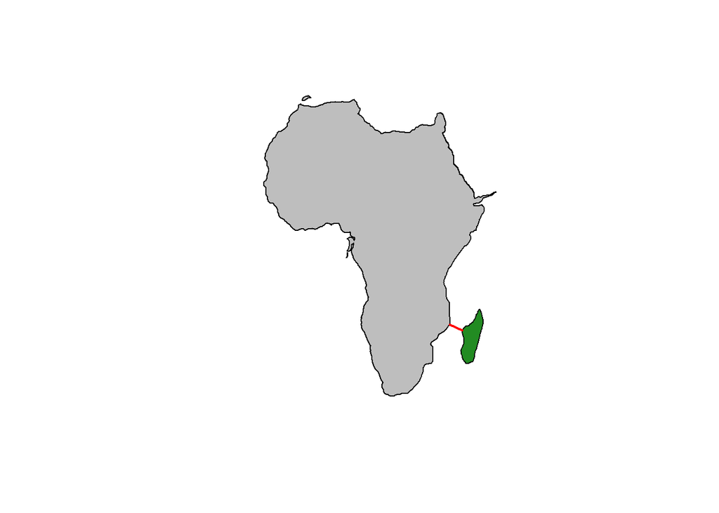

```
Processing 20 Ma
```

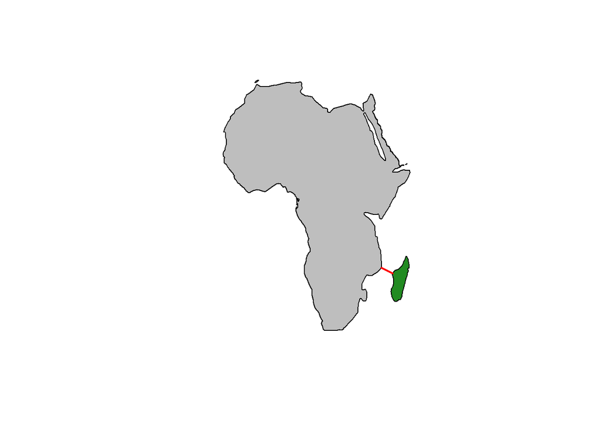

```
Processing 15 Ma
```

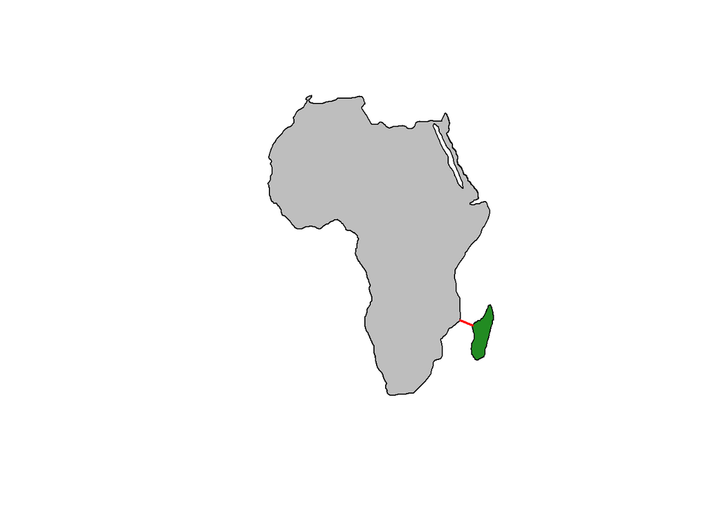

```
Processing 10 Ma
```

[3 more figures not shown]

```r
results <- vector("list", length(ages))

for (i in seq_along(ages)) {
  age <- ages[i]

  message("Processing ", age, " Ma")
  # Area

  ## Africa:

  africa_i_ea <- afr_list[[i]] %>%
    sf::st_transform(aea)

  africa_area_km2 <-
    africa_i_ea %>%
    st_area() %>%
    as.numeric() /
    1e6

  ## Madagascar

  madagascar_i_ea <- mda_list[[i]] %>%
    sf::st_transform(aea)

  madagascar_area_km2 <-
    madagascar_i_ea %>%
    st_area() %>%
    as.numeric() /
    1e6

  # Distance

  ## Distance between nearest points:
  nearest <-
    st_nearest_points(africa_i_ea, madagascar_i_ea)

  ## Plot the distance:
  plot(st_geometry(africa_i_ea), col = "grey")
  plot(st_geometry(madagascar_i_ea), col = "forestgreen", add = TRUE)
  plot(nearest, col = "red", lwd = 2, add = TRUE)

  ## Convert to km
  nearest_km <- as.numeric(st_length(nearest)) / 1000

  # save to results dataframe
  results[[i]] <-
    data.frame(
      age_ma = age,
      africa_area_km2 = africa_area_km2,
      madagascar_area_km2 = madagascar_area_km2,
      nearest_km = nearest_km
    )
}
```

```r
results_df <- bind_rows(results)
results_df
```

```
   age_ma africa_area_km2 madagascar_area_km2 nearest_km
1      80        15244979            467249.1   802.0510
2      70        18550722            485071.8   457.1242
3      65        20411427            425103.4   515.0815
4      60        22322590            492961.8   448.3698
5      50        23066095            502815.0   489.4111
6      45        25046940            540309.4   424.8481
7      40        25958651            542918.1   401.4585
8      35        26792027            566669.7   387.1685
9      30        27310483            529716.6   421.9636
10     25        28338474            552214.2   400.2902
11     20        27919346            512462.6   451.4993
12     15        28825734            566199.2   405.9195
13     10        29260878            536091.1   434.2004
14      5        29212990            565691.1   417.4973
15      0        28812038            509040.8   447.4678
```

### 5. Convert to FIG-model format

1. Age_summary.csv

```r
age_summary <-
  data.frame(
    index = seq(from = 15, to = 1),
    end_age = as.numeric(results_df$age_ma),
    feature_dir = paste0("time", seq(from = 15, to = 1))
  ) %>%
  arrange(index)


age_summary2 <-
  age_summary %>%
  data.frame(
    start_age = age_summary$end_age + 5
  ) %>%
  mutate(mean_age = (age_summary$end_age + start_age) / 2)


age_summary2 <-
  age_summary2 %>%
  select(index, mean_age, start_age, end_age, feature_dir)
```

```r
write.csv(
  age_summary2,
  here::here("data/output/paleo/age_summary.csv"),
  row.names = FALSE
)
```

```r
for (i in seq_along(ages)) {
  dir.create(paste0(here::here("data/output/paleo//"), "time", i))
}
```

```r
results_df2 <-
  results_df %>%
  mutate(index = seq(from = 15, to = 1)) %>%
  arrange(index)

for (i in seq_len(nrow(results_df2))) {
  out1 <- data.frame(
    A = results_df2$africa_area_km2[i],
    M = results_df2$madagascar_area_km2[i]
  )

  write.csv(
    out1,
    file = paste0(
      here::here("data/output/paleo//"),
      "time",
      i,
      "/",
      "qw_feature1.csv"
    ),
    row.names = FALSE
  )

  out2 <-
    data.frame(
      A = log(results_df2$africa_area_km2[i]),
      M = log(results_df2$madagascar_area_km2[i])
    )

  write.csv(
    out2,
    file = paste0(
      here::here("data/output/paleo//"),
      "time",
      i,
      "/",
      "qw_feature2.csv"
    ),
    row.names = FALSE
  )
}
```

```r
results_df2 <-
  results_df %>%
  mutate(index = seq(from = 15, to = 1)) %>%
  arrange(index)

for (i in seq_len(nrow(results_df2))) {
  out1 <- data.frame(
    A = c(1, results_df2$nearest_km[i]),
    M = c(results_df2$nearest_km[i], 1)
  )
  print(out1)
  write.csv(
    out1,
    file = paste0(
      here::here("data/output/paleo//"),
      "time",
      i,
      "/",
      "qb_feature1.csv"
    ),
    row.names = FALSE
  )

  out2 <- data.frame(
    A = log(c(1, results_df2$nearest_km[i])),
    M = log(c(results_df2$nearest_km[i], 1))
  )

  write.csv(
    out2,
    file = paste0(
      here::here("data/output/paleo//"),
      "time",
      i,
      "/",
      "qb_feature2.csv"
    ),
    row.names = FALSE
  )
}
```

```
         A        M
1   1.0000 447.4678
2 447.4678   1.0000
         A        M
1   1.0000 417.4973
2 417.4973   1.0000
         A        M
1   1.0000 434.2004
2 434.2004   1.0000
         A        M
1   1.0000 405.9195
2 405.9195   1.0000
         A        M
1   1.0000 451.4993
2 451.4993   1.0000
         A        M
1   1.0000 400.2902
2 400.2902   1.0000
         A        M
1   1.0000 421.9636
2 421.9636   1.0000
         A        M
1   1.0000 387.1685
2 387.1685   1.0000
         A        M
1   1.0000 401.4585
2 401.4585   1.0000
         A        M
1   1.0000 424.8481
2 424.8481   1.0000
         A        M
1   1.0000 489.4111
2 489.4111   1.0000
         A        M
1   1.0000 448.3698
2 448.3698   1.0000
         A        M
1   1.0000 515.0815
2 515.0815   1.0000
         A        M
1   1.0000 457.1242
2 457.1242   1.0000
        A       M
1   1.000 802.051
2 802.051   1.000
```

Categorical variables 1. cw1 = Age Class (0 = old, 1 = young) 2. cb1 = Dispersal Class (0 = short, 1 = long) 3. cw2 = Growth Class (0 = decay, 1 = growth) 4. cb2 = Relative age class (0 = older, 1 = younger)

```r
results_df2 <-
  results_df %>%
  mutate(index = seq(from = 15, to = 1)) %>%
  arrange(index)

tibble(results_df2)
```

```
# A tibble: 15 × 5
   age_ma africa_area_km2 madagascar_area_km2 nearest_km index
   <chr>            <dbl>               <dbl>      <dbl> <int>
 1 0            28812038.             509041.       447.     1
 2 5            29212990.             565691.       417.     2
 3 10           29260878.             536091.       434.     3
 4 15           28825734.             566199.       406.     4
 5 20           27919346.             512463.       451.     5
 6 25           28338474.             552214.       400.     6
 7 30           27310483.             529717.       422.     7
 8 35           26792027.             566670.       387.     8
 9 40           25958651.             542918.       401.     9
10 45           25046940.             540309.       425.    10
11 50           23066095.             502815.       489.    11
12 60           22322590.             492962.       448.    12
13 65           20411427.             425103.       515.    13
14 70           18550722.             485072.       457.    14
15 80           15244979.             467249.       802.    15
```

1. cw1 should be 1 for all areas and time slices…

```r
out <- data.frame(
  "A" = 1,
  "M" = 1
)

for (i in seq_along(ages)) {
  write.csv(
    out,
    file = paste0(
      here::here("data/output/paleo//"),
      "time",
      i,
      "/",
      "cw_feature1.csv"
    ),
    row.names = FALSE
  )
}
```

2. cb1 should be dependent on oceanic currents… to do: read up on currents and timings to make a more informed choice!! (26-06-2026)

…until then let’s go with distance-based. (short if below 401 km - just to see if there is an influence on the outcome)

```r
for (i in seq_len(nrow(results_df2))) {
  time <- results_df2[i, ]

  if (time$nearest_km > 401) {
    out1 <- data.frame(
      A = c(0, 1),
      M = c(1, 0)
    )

    print(out1)

    write.csv(
      out1,
      file = paste0(
        here::here("data/output/paleo//"),
        "time",
        i,
        "/",
        "cb_feature1.csv"
      ),
      row.names = FALSE
    )
  } else {
    out2 <- data.frame(
      A = c(0, 0),
      M = c(0, 0)
    )

    write.csv(
      out2,
      file = paste0(
        here::here("data/output/paleo//"),
        "time",
        i,
        "/",
        "cb_feature1.csv"
      ),
      row.names = FALSE
    )
  }
}
```

```
  A M
1 0 1
2 1 0
  A M
1 0 1
2 1 0
  A M
1 0 1
2 1 0
  A M
1 0 1
2 1 0
  A M
1 0 1
2 1 0
  A M
1 0 1
2 1 0
  A M
1 0 1
2 1 0
  A M
1 0 1
2 1 0
  A M
1 0 1
2 1 0
  A M
1 0 1
2 1 0
  A M
1 0 1
2 1 0
  A M
1 0 1
2 1 0
  A M
1 0 1
2 1 0
```

3. cw2 will depend only on the area size

```r
for (i in seq_len(nrow(results_df2))) {
  time_i <-
    results_df2[i, ]
  time_i_2 <-
    results_df2[i + 1, ]

  Afr <-
    ifelse(time_i$africa_area_km2 - time_i_2$africa_area_km2 < 0, 0, 1)
  Mda <-
    ifelse(time_i$madagascar_area_km2 - time_i_2$madagascar_area_km2 < 0, 0, 1)

  out <-
    data.frame(Afr, Mda)

  if (i == 15) {
    out <- data.frame(Afr = 1, Mda = 1)
  }

  print(out)

  write.csv(
    out,
    file = paste0(
      here::here("data/output/paleo//"),
      "time",
      i,
      "/",
      "cw_feature2.csv"
    ),
    row.names = FALSE
  )
}
```

```
  Afr Mda
1   0   0
  Afr Mda
1   0   1
  Afr Mda
1   1   0
  Afr Mda
1   1   1
  Afr Mda
1   0   0
  Afr Mda
1   1   1
  Afr Mda
1   1   0
  Afr Mda
1   1   1
  Afr Mda
1   1   1
  Afr Mda
1   1   1
  Afr Mda
1   1   1
  Afr Mda
1   1   1
  Afr Mda
1   1   0
  Afr Mda
1   1   1
  Afr Mda
1   1   1
```

```r
out <- data.frame(
  "A" = c(1, 1),
  "M" = c(1, 1)
)

for (i in seq_along(ages)) {
  write.csv(
    out,
    file = paste0(
      here::here("data/output/paleo//"),
      "time",
      i,
      "/",
      "cb_feature2.csv"
    ),
    row.names = FALSE
  )
}
```

Make the feature_summary.csv

```r
feature_df <- expand.grid(
  time_index = 1:15,
  feature_index = 1:2,
  feature_relationship = c("within", "between"),
  feature_type = c("categorical", "quantitative"),
  KEEP.OUT.ATTRS = FALSE,
  stringsAsFactors = FALSE
)

feature_df$prefix <- with(
  feature_df,
  paste0(
    ifelse(feature_type == "categorical", "c", "q"),
    ifelse(feature_relationship == "within", "w", "b")
  )
)

feature_df$feature_path <- with(
  feature_df,
  paste0(
    "./data/output/paleo/time",
    time_index,
    "/",
    prefix,
    "_feature",
    feature_index,
    ".csv"
  )
)

feature_df$prefix <- NULL

write.csv(
  feature_df,
  file = here::here("data/output/paleo/feature_summary.csv"),
  row.names = FALSE,
  quote = FALSE
)
```